# Relation

# 要素がひとつだけの場合

ジェノタイプ $G=\{0,1,2\}$

ジェノタイプ依存性フェノタイプ1 $P_1 \sim N(f(G),\sigma_1)$

$P_1$依存性疾患フェノタイプ $F \sim Bernoulli(h(P_1))$

多項式モデル

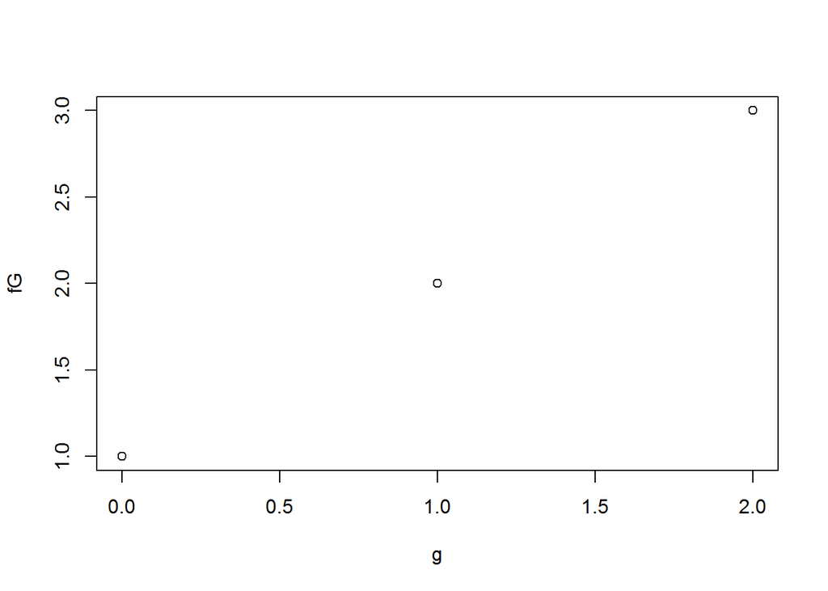

```r
f.G <- function(g,a){
  ret <- rep(0,length(g))
  for(i in 1:length(a)){
    ret <- ret + g^(i-1)*a[i]
  }
  return(ret)
}
N <- 1000
p <- 0.3
g <- sample(0:2,N,replace=TRUE,prob= c(p^2,2*p*(1-p),(1-p)^2))
a <- c(1,1)
fG <- f.G(g,a)
plot(g,fG)
```

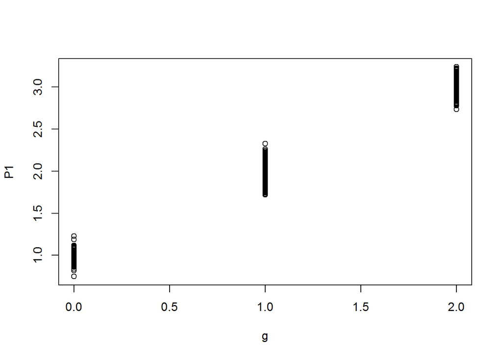

```r
sigma1 <- 0.1
P1 <- rep(0,N)
for(i in 1:N){
  P1[i] <- rnorm(1,fG[i],sd=sigma1)
}
plot(g,P1)
```

多項式指数関数モデル $\frac{e^{h'(p1)}}{e^{h'(p1)}+1}$

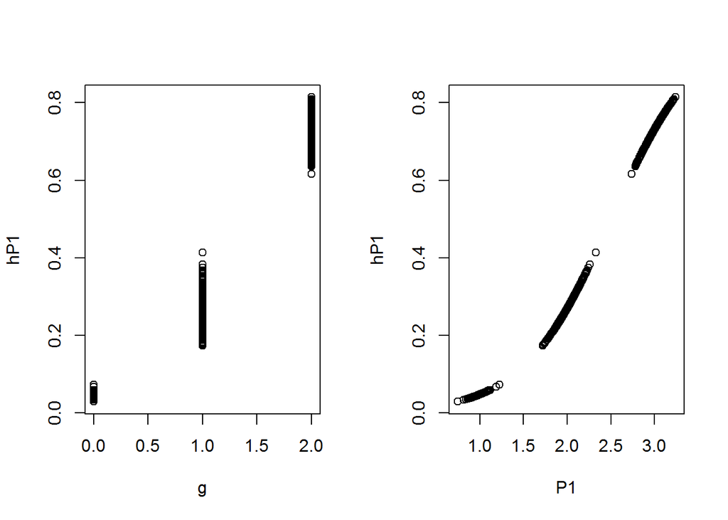

```r
h.P <- function(p,b){
  ret <- rep(0,length(p))
  for(i in 1:length(a)){
    ret <- ret + p^(i-1)*b[i]
  }
  ret2 <- exp(ret)/(exp(ret)+1)
  return(ret2)
}
b <- c(-5,2)
hP1 <- h.P(P1,b)
par(mfcol=c(1,2))
plot(g,hP1)
plot(P1,hP1)
```

```r
par(mfcol=c(1,1))
```

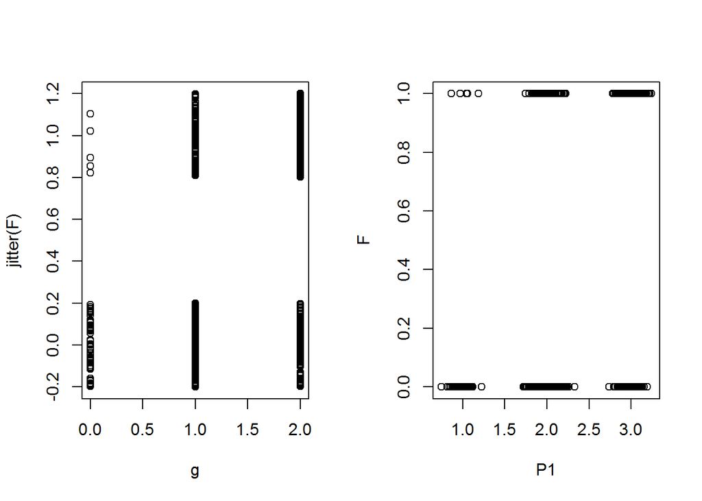

```r
sigma2 <- 1
F <- rep(0,N)
for(i in 1:N){
  F[i] <- sample(1:0,1,prob=c(hP1[i],1-hP1[i]))
}
par(mfcol=c(1,2))
plot(g,jitter(F))
plot(P1,F)
```

```r
par(mfcol=c(1,1))
```

# 要素が２つあって、それらの間にエッジが引かれているパスウェイの場合

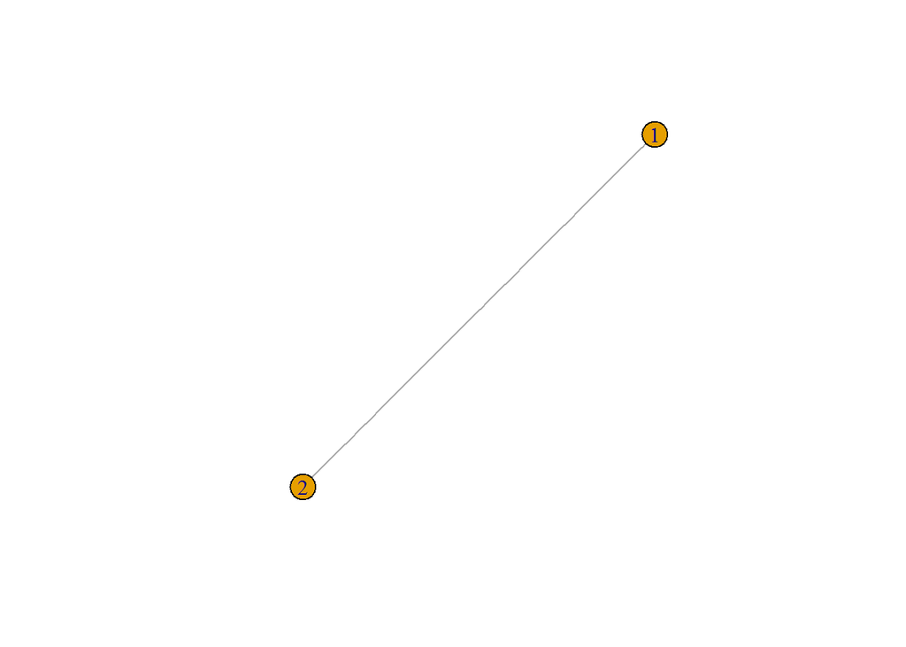

```r
library(igraph)
gr <- graph.edgelist(matrix(c(1,2),nrow=1),directed=FALSE)
plot(gr)
```

上記は$G_1 -> P_1 \sim N(f(G_1)) -> F \sim Bernoulli(h(P_1))$

というモデル。

これを $G_i; i=1,2$, $P_i; i=1,2$とする。

1. $P_1$と$P_2$の間にエッジがあるということは、$P_1$の値と$P_2$の値との間に関連があるということ。(その関係は$G_1$と$G_2$との間の関係(連鎖不平衡などによる偽の関係ではないと考えている))
2. パスウェイ($P_1,P_2$とそれらを結ぶエッジ)が$F$に影響するということは、$P_1$の値と$P_2$の値と、その2つの値の関係との3要素が$F$に影響を与えるということ。
3. で$P_1$と$P_2$との間に関係があれば、$F$が$P_1$と$P_2$とに影響されさえすれば、パスウェイと$F$とが関係する、ということにはなる。パスウェイのダイナミズムが$F$に関係するとすれば、$P_1$と$P_2$との相互作用項を$F$への影響因子に入れたモデルを考えることになる。

逆に、(1)における$P_1$、$P_2$の値に相互関係がなくても、(2)において$P_1$,$P_2$の相互作用が$F$に影響するというモデルを立てれば、それもパスウェイが$F$に影響するというモデルになる。

(1)と(2)との両方があってももちろんよい。

## あるモデル

$P_1 \sim N(f1(G_1),\sigma_1)$

$P_2$は$G_2$の影響も受ける(かも知れない)が、$P_1$の影響を受ける。 $P_2 \sim N(k(G_2,P_1),\sigma_2)$

$F \sim Bernoulli(h'(P_1,P_2,P_1 \times P_2))$

```r
N <- 1000
p1 <- 0.3
g1 <- sample(0:2,N,replace=TRUE,prob= c(p1^2,2*p1*(1-p1),(1-p1)^2))
a1 <- c(1,1)
fG1 <- f.G(g1,a1)
sigma1 <- 0.1
P1 <- rep(0,N)
for(i in 1:N){
  P1[i] <- rnorm(1,fG[i],sd=sigma1)
}
```

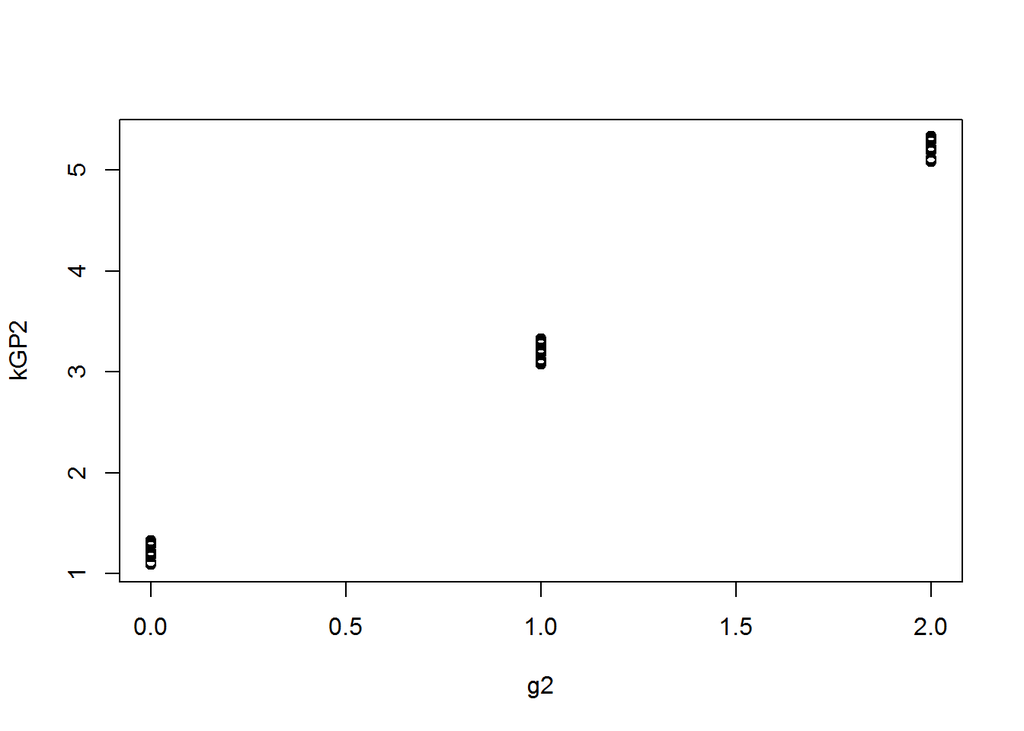

```r
p2 <- 0.4
g2 <- sample(0:2,N,replace=TRUE,prob= c(p2^2,2*p2*(1-p2),(1-p2)^2))
a2 <- c(1,2)
a22 <- c(0,1)

# P1のP2への影響を調節する
p1.p2 <- 0.1 # 0なら、影響なし
kGP2 <- f.G(g2,a2) + p1.p2 * f.G(P1,a22)
plot(g2,kGP2)
```

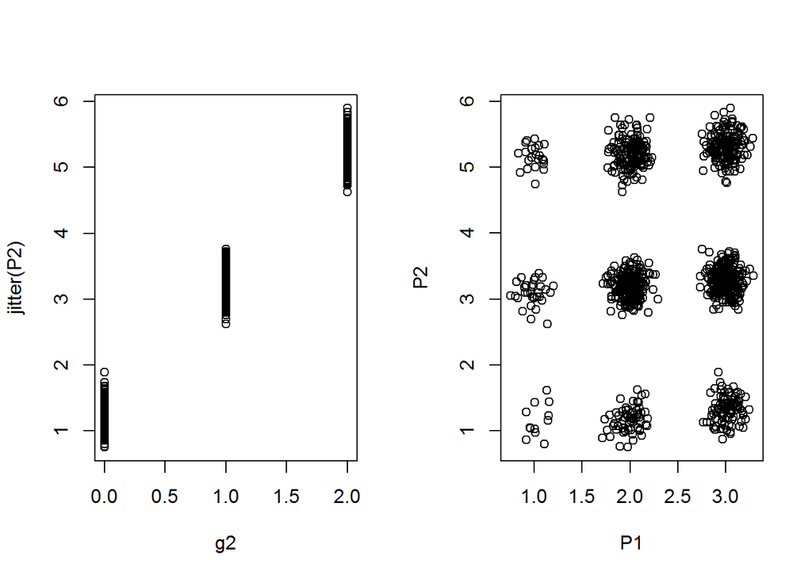

```r
sigma2 <- 0.2
P2 <- rep(0,N)
for(i in 1:N){
  P2[i] <- rnorm(1,kGP2[i],sd=sigma2)
}
par(mfcol=c(1,2))
plot(g2,jitter(P2))
plot(P1,P2)
```

```r
par(mfcol=c(1,1))
```

$P_1,P_2,P_1 \times P_2$を考慮するためには、

$P_1,P_1^2,P_1^3,...$と$P_2,P_2^2,P_2^3,...$とに加えて、$P_1 \times P_2, P_1^2 \times P_2$という項も考慮することになる。

$F \sim Bernoulli(h(P_1,P_2))$ の$h()$を定めよう。

$h(P_1,P_2) = \frac{e^{H(P_1,P_2)}}{e^{H(P_1,P_2)}+1}$とし、 $H(P_1,P_2) = b_0 + b_1 \frac{P_2}{P_1}$ だとどうなるだろうか。

意図としては、P1の影響でP2が増えるという機構が更新しているということを、$\frac{P_2}{P_1}$と言う値で表してみたことに相当する。

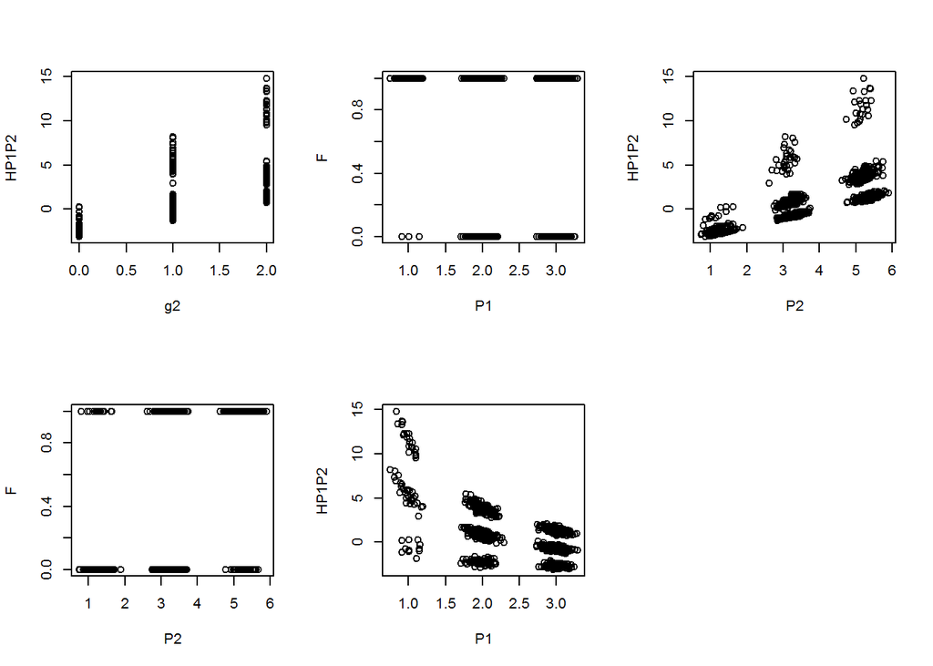

```r
b <- c(-4,3)
HP1P2 <- b[1] + b[2] * P2/P1
hP1P2 <- exp(HP1P2)/(exp(HP1P2)+1)
sigma2 <- 1
F <- rep(0,N)
for(i in 1:N){
  F[i] <- sample(1:0,1,prob=c(hP1P2[i],1-hP1P2[i]))
}
par(mfcol=c(2,3))
plot(g2,HP1P2)
plot(P2,F)
plot(P1,F)
plot(P1,HP1P2)
plot(P2,HP1P2)
par(mfcol=c(1,1))
```

# これはおまけ。多項式関数を適当に定義してやるのも、もちろんあり。モデル多項式を体系的に作成して、検討するには、モデル関数を作る関数を作っておくほうがよい、という参考

一般的にn要素多項式モデルを関数化してみる。

$P_1^{u_1}P_2^{u_2}...P_n^{u_n}$なる項を考え、$\sum_{i=1}^n u_i \le U$でモデル化するとする。

自然数$(0,)1,2,...U$の$n$-分割のすべてに係数を割り振ることに相当する。 以下のparts(u)関数は、uの分割のすべてを restrictedparts(u,v)は、uをvつの自然数への分割のすべてを それぞれ列挙する。

```r
library(partitions)
parts(3)
```

```
##
## [1,] 3 2 1
## [2,] 0 1 1
## [3,] 0 0 1
```

```r
restrictedparts(3,2)
```

```
##
## [1,] 3 2
## [2,] 0 1
```

```r
blockparts(1:3,4)
```

```
##
## [1,] 1 1 0 1 0
## [2,] 2 1 2 0 1
## [3,] 1 2 2 3 3
```

```r
blockparts(rep(3,3),4)
```

```
##
## [1,] 3 2 1 3 2 1 0 2 1 0 1 0
## [2,] 1 2 3 0 1 2 3 0 1 2 0 1
## [3,] 0 0 0 1 1 1 1 2 2 2 3 3
```

```r
blockparts(rep(3,3),4,include.fewer=TRUE)
```

```
##
## [1,] 0 1 2 3 0 1 2 3 0 1 2 0 1 0 1 2 3 0 1 2 0 1 0 0 1 2 0 1 0 0 1 0
## [2,] 0 0 0 0 1 1 1 1 2 2 2 3 3 0 0 0 0 1 1 1 2 2 3 0 0 0 1 1 2 0 0 1
## [3,] 0 0 0 0 0 0 0 0 0 0 0 0 0 1 1 1 1 1 1 1 1 1 1 2 2 2 2 2 2 3 3 3
```

```
U <- 3
n <- 4
partslist <- list()
for(i in 0:U){
 partslist[[i+1]] <- blockparts(1:n,i)
}
partslist
```

これを使って、変数の数がn、最大次数がUの多項式係数を与えることにする。

```r
make.polycoeffs.zeros <- function(n,U){
  blpts <- blockparts(rep(U,n),U,include.fewer=TRUE)
  coeffs <- rep(0,ncol(blpts))
  return(list(coeffs=coeffs,blpts=blpts))
}
make.polycoeffs.zeros(3,4)
```

```
## $coeffs
##  [1] 0 0 0 0 0 0 0 0 0 0 0 0 0 0 0 0 0 0 0 0 0 0 0 0 0 0 0 0 0 0 0 0 0 0 0
##
## $blpts
##
## [1,] 0 1 2 3 4 0 1 2 3 0 1 2 0 1 0 0 1 2 3 0 1 2 0 1 0 0 1 2 0 1 0 0 1 0 0
## [2,] 0 0 0 0 0 1 1 1 1 2 2 2 3 3 4 0 0 0 0 1 1 1 2 2 3 0 0 0 1 1 2 0 0 1 0
## [3,] 0 0 0 0 0 0 0 0 0 0 0 0 0 0 0 1 1 1 1 1 1 1 1 1 1 2 2 2 2 2 2 3 3 3 4
```

モデルの作成にあたっては、make.polycoeffs.zeros()関数の出力のhoge$coeffsというリストの適当なところに適当な値を付値する。

この係数格納オブジェクトを用いて、多項式の値を求める関数を作る。

```r
val.polycoeffs <- function(X,pc){
  N <- length(X[,1])
  ret <- rep(0,N)
  for(i in 1:length(pc$coeffs)){
    tmp <- rep(1,N)
    for(j in 1:length(pc$blpts[,i])){
      tmp <- tmp * X[,j]^pc$blpts[j,i]
    }
    ret <- ret + tmp*pc$coeffs[i]
  }
  return(ret)
}
```

使ってみる。 $f(x1,x2,x3) = 3 + 2x1 + x2 - x3 + 2 x1\times x2 + 3 x3^2$

```r
n <- 3
U <- 2
pc <- make.polycoeffs.zeros(n,U)
pc
```

```
## $coeffs
##  [1] 0 0 0 0 0 0 0 0 0 0
##
## $blpts
##
## [1,] 0 1 2 0 1 0 0 1 0 0
## [2,] 0 0 0 1 1 2 0 0 1 0
## [3,] 0 0 0 0 0 0 1 1 1 2
```

```r
pc$coeffs[1] <- 3
pc$coeffs[2] <- 2
pc$coeffs[4] <- 1
pc$coeffs[7] <- -1
pc$coeffs[5] <- 2
pc$coeffs[10] <- 3
pc
```

```
## $coeffs
##  [1]  3  2  0  1  2  0 -1  0  0  3
##
## $blpts
##
## [1,] 0 1 2 0 1 0 0 1 0 0
## [2,] 0 0 0 1 1 2 0 0 1 0
## [3,] 0 0 0 0 0 0 1 1 1 2
```

```r
X <- rbind(c(0,0,0),c(1,0,0),c(0,1,0),c(0,0,1),c(1,1,1),rnorm(3))
X
```

```
##            [,1]       [,2]      [,3]
## [1,]  0.0000000  0.0000000 0.0000000
## [2,]  1.0000000  0.0000000 0.0000000
## [3,]  0.0000000  1.0000000 0.0000000
## [4,]  0.0000000  0.0000000 1.0000000
## [5,]  1.0000000  1.0000000 1.0000000
## [6,] -0.2268368 -0.1327374 0.5958538
```

```r
val.polycoeffs(X,pc)
```

```
## [1]  3.00000  5.00000  4.00000  5.00000 10.00000  2.94308
```

```r
my.f <- function(X){
  3 + 2*X[,1] + X[,2] - X[,3] + 2* X[,1]*X[,2] + 3*X[,3]^2
}
my.f(X)
```

```
## [1]  3.00000  5.00000  4.00000  5.00000 10.00000  2.94308
```